# Network Analysis in R

Lessons from DataCamp

# Introduction

The following documentoutlines the written portion of the lessons from [DataCamp](https://www.datacamp.com/)’s [Network Analysis in R course](https://www.datacamp.com/courses/network-analysis-in-r). This primarily uses the “igraph” package and requires Intermediate knowledge of R.

As a note: All text is completely copied and pasted from the course. There are instances where the document refers to the “editor on the right”, please note, that in this notebook document all of the instances are noted in the “r-chunks” (areas containing working r-code), which occurs below the text, rather than to the right. Furthermore, This lesson contained instructional videos at the begining of new concepts that are not detailed in this document. However, even without these videos, the instructions are quite clear in indicating what the code is accomplishing.

This document was created by Neil Yetz on 02/14/2018. Please send any questions or concerns in this document to Neil at ndyetz@gmail.com

[figure not shown]

## Required packages for this session

Below are the install.packages and libraries you will need to have in order to run this session succesfully.

```r
#install.packages("igraph")
#install.packages("tidyverse")
#install.packages("threejs")
library(igraph)
library(tidyverse)
library(threejs)
```

## Required data for this session

```r
friends         <- read_csv("friends.csv")
friends1_edges  <- read_csv("friends1_edges.csv")
friends1_nodes  <- read_csv("friends1_nodes.csv")
gump            <- read_csv("gump.csv")
measles         <- read_csv("measles.csv")
chimps          <- read_csv("monkeys.csv")
kc              <- as.matrix(read_csv("karate_class.csv", col_names = FALSE))
```

# Course Description

In this course you’ll learn how to work with and visualize network data. You’ll use the `igraph` package to create networks from edgelists and adjacency matrices. You’ll also learn how to plot networks and their attributes. Then, you’ll learn how to identify important vertices using measures like betweenness and degree. Next, this course covers network structures, including triangles and cliques. Next, you’ll learn how to identify special relationships between vertices, using metrics like assortativity. Finally, you’ll see how to create interactive network plots using threejs.

# Chapter 1: Introduction to Networks

In this chapter, you will be introduced to fundamental concepts in social network analysis. You will learn how to use the `igraph` R package to explore and analyze social network data as well as learning how to visualize networks.

## Creating an Igraph Object

Here you will learn how to create an `igraph` ‘object’ from data stored in an edgelist. The data are friendships in a group of students. You will also learn how to make a basic visualization of the network.

Each row of the friends dataframe represents an edge in the network.

**INSTRUCTIONS**

Inspect the first few rows of the dataframe `friends` using the function `head()`.

Create new object `friends.mat` from the dataframe `friends` using `as.matrix()`.

Convert variable to an igraph object `g` using `graph.edgelist()`.

Make a basic plot of the network using `plot()`.

```r
# Load igraph
library(igraph)
# Inspect the first few rows of the dataframe 'friends'
head(friends)
```

| name1 | name2 |
| --- | --- |
| Jessie | Sidney |
| Jessie | Britt |
| Sidney | Britt |
| Sidney | Donnie |
| Karl | Berry |
| Sidney | Rene |

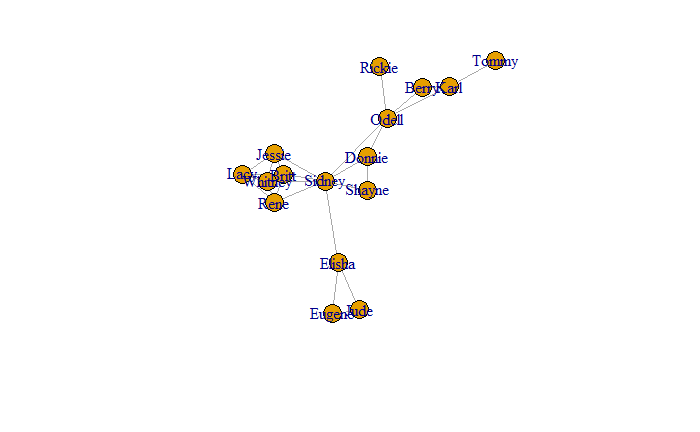

```r
# Convert friends dataframe to a matrix
friends.mat <- as.matrix(friends)
# Convert friends matrix to an igraph object
g <- graph.edgelist(friends.mat, directed = FALSE)
# Make a very basic plot of the network
plot(g)
```

## Counting vertices and edges

A lot of basic information about a network can be extracted from an `igraph` object. In this exercise you will learn how to count the vertices and edges from a network by applying several functions to the graph object `g`.

Each row of the friends dataframe represents an edge in the network.

**INSTRUCTIONS**

Use `V()` and `E()` to view the vertices and edges respectively of the network. Use `gsize()` to count the number of edges in a network. Use `gorder()` to count the number of vertices in a network.

```r
# Load igraph
library(igraph)
# Subset vertices and edges
V(g)
```

```
+ 16/16 vertices, named, from 5207b0e:
 [1] Jessie  Sidney  Britt   Donnie  Karl    Berry   Rene    Shayne  Elisha  Whitney Odell   Lacy    Eugene  Jude    Rickie  Tommy
```

```r
E(g)
```

```
+ 27/27 edges from 5207b0e (vertex names):
 [1] Jessie --Sidney  Jessie --Britt   Sidney --Britt   Sidney --Donnie  Karl   --Berry   Sidney --Rene    Britt  --Rene    Sidney --Shayne
 [9] Sidney --Elisha  Sidney --Whitney Jessie --Whitney Donnie --Odell   Sidney --Odell   Rene   --Whitney Donnie --Shayne  Jessie --Lacy
[17] Rene   --Lacy    Elisha --Eugene  Eugene --Jude    Berry  --Odell   Odell  --Rickie  Karl   --Odell   Britt  --Lacy    Elisha --Jude
[25] Whitney--Lacy    Britt  --Whitney Karl   --Tommy
```

```r
# Count number of edges
gsize(g)
```

```
[1] 27
```

```r
# Count number of vertices
gorder(g)
```

```
[1] 16
```

## Node attributes and subsetting

In this exercise you will learn how to add attributes to vertices in the network and view them.

**INSTRUCTIONS**

Create a new vertex attribute called ‘gender’ from the vector `genders` using `set_vertex_attr()`.

Create a new vertex attribute called ‘age’ from the vector `ages` using `set_vertex_attr()`.

View all vertex attributes using `vertex_attr()`.

View the attributes of the first five vertices in a dataframe using `V(g)[[]]`.

```r
library(igraph)
# Inspect the objects 'genders' and 'ages'
genders
```

```
 [1] "M" "F" "F" "M" "M" "M" "F" "M" "M" "F" "M" "F" "M" "F" "M" "M"
```

```r
ages
```

```
 [1] 18 19 21 20 22 18 23 21 22 20 20 22 21 18 19 20
```

```r
# Create new vertex attribute called 'gender'
g <- set_vertex_attr(g, "gender", value = genders)
# Create new vertex attribute called 'age'
g <- set_vertex_attr(g, "age", value = ages)
# View all vertex attributes in a list
vertex_attr(g)
```

```
$name
 [1] "Jessie"  "Sidney"  "Britt"   "Donnie"  "Karl"    "Berry"   "Rene"    "Shayne"  "Elisha"  "Whitney" "Odell"   "Lacy"    "Eugene"  "Jude"
[15] "Rickie"  "Tommy"

$gender
 [1] "M" "F" "F" "M" "M" "M" "F" "M" "M" "F" "M" "F" "M" "F" "M" "M"

$age
 [1] 18 19 21 20 22 18 23 21 22 20 20 22 21 18 19 20
```

```r
# View attributes of first five vertices in a dataframe
V(g)[[1:5]]
```

```
+ 5/16 vertices, named, from 5207b0e:
    name gender age
1 Jessie      M  18
2 Sidney      F  19
3  Britt      F  21
4 Donnie      M  20
5   Karl      M  22
```

## Edge attributes and subsetting

In this exercise you will learn how to add attributes to edges in the network and view them. For instance, we will add the attribute ‘hours’ that represents how many hours per week each pair of friends spend with each other.

**Instructions**

Create a new edge attribute called ‘hours’ from the vector `hours` using `set_edge_attr()`.

View all edge attributes using `edge_attr()`.

View all edges that include the person “Britt”.

View all edges where the attribute `hours` is greater than or equal to 4 hours.

```r
library(igraph)
# View hours
hours
```

```
 [1] 1 2 2 1 2 5 5 1 1 3 2 1 1 5 1 2 4 1 3 1 1 1 4 1 3 3 4
```

```r
# Create new edge attribute called 'hours'
g <- set_edge_attr(g, "hours", value = hours)
# View edge attributes of graph object
edge_attr(g)
```

```
$hours
 [1] 1 2 2 1 2 5 5 1 1 3 2 1 1 5 1 2 4 1 3 1 1 1 4 1 3 3 4
```

```r
# Find all edges that include "Britt"
E(g)[[inc('Britt')]]
```

```
+ 5/27 edges from 5207b0e (vertex names):
     tail    head tid hid hours
2  Jessie   Britt   1   3     2
3  Sidney   Britt   2   3     2
7   Britt    Rene   3   7     5
23  Britt    Lacy   3  12     4
26  Britt Whitney   3  10     3
```

```r
# Find all pairs that spend 4 or more hours together per week
E(g)[[hours>=4]]
```

```
+ 6/27 edges from 5207b0e (vertex names):
     tail    head tid hid hours
6  Sidney    Rene   2   7     5
7   Britt    Rene   3   7     5
14   Rene Whitney   7  10     5
17   Rene    Lacy   7  12     4
23  Britt    Lacy   3  12     4
27   Karl   Tommy   5  16     4
```

## Visualizing attributes

In this exercise we will learn how to create igraph objects with attributes directly from dataframes and how to visualize attributes in plots. We will use a second network of friendship connections between students.

**INSTRUCTIONS**

Create a new igraph object with `graph_from_data_frame()`.Two dataframes need to be provided - friends1_edges contains all edges in the network with attributes and friends1_nodes contains all vertices in the network with attributes.

View all edges where the attribute `hours` is greater than or equal to 5 hours.

Create a new vertex attribute containing color names: orange for females and dodgerblue for males.

Plot the network with vertices colored by gender and make label names black.

```r
library(igraph)
# Create an igraph object with attributes directly from dataframes
g1 <- graph_from_data_frame(d = friends1_edges, vertices = friends1_nodes, directed = FALSE)
# Subset edges greater than or equal to 5 hours
E(g1)[[hours>=5]]
```

```
+ 4/25 edges from 55acacf (vertex names):
        tail      head tid hid hours
5     Kelley Valentine   3   6     5
8     Ronald   Jasmine   4   8     5
12 Valentine     Perry   6  15     5
15   Jasmine      Juan   8   9     6
```

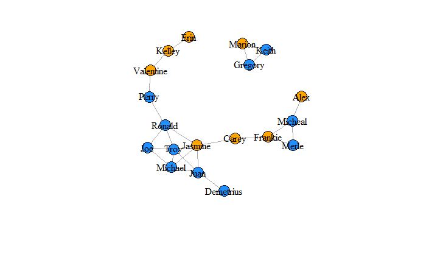

```r
# Plot network and color vertices by gender
V(g1)$color <- ifelse(V(g1)$gender == "F", "orange", "dodgerblue")
plot(g1, vertex.label.color = "black")
```

### Quiz on attributes

What term is typically used to describe the relative strength of edges? (Answer is **Bolded**)

Possible Answers

- Distance
- **Weight**
- Direction
- Length

## igraph network layouts

The `igraph` package provides several built in layout algorithms for network visualization. Depending upon the size of a given network different layouts may be more effective in communicating the structure of the network. Ideally the best layout is the one that minimizes the number of edges that cross each other in the network. In this exercise you will explore just a few of the many default layout algorithms. Re-executing the code for each plot will lead to a slightly different version of the same layout type. Doing this a few times can help to find the best looking visualization for your network.

**INSTRUCTIONS**

In the plot function, change the layout argument to `layout_in_circle()` to produce a circle network.

In the plot function, change the `layout` argument to `layout_with_fr()` to produce a network with the Fruchterman-Reingold layout.

You can also stipulate the layout by providing a matrix of (x, y) coordinates for each vertex. Here you use the `layout_as_tree()` function to generate the matrix `m` of coordinates. Then pass `m` to the layout function in `plot()` to plot.

Choosing a correct layout can be bewildering. Fortunately `igraph` has a function `layout_nicely()` that tries to choose the most appropriate layout function for a given graph object. Use this function to produce the matrix `m1` and plot the network using these coordinates.

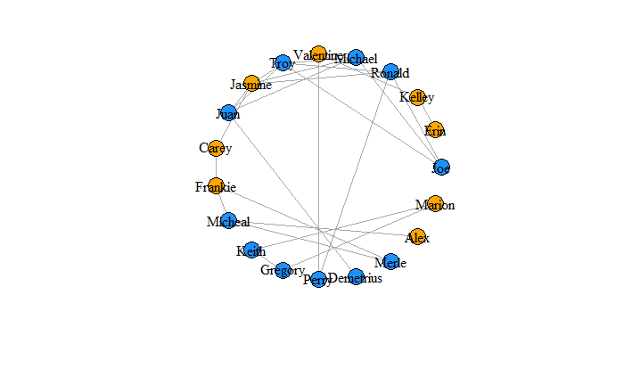

```r
library(igraph)
# Plot the graph object g1 in a circle layout
plot(g1, vertex.label.color = "black", layout = layout_in_circle(g1))
```

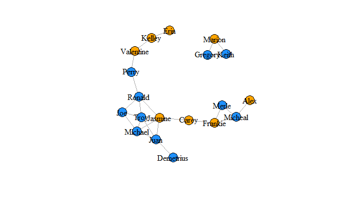

```r
# Plot the graph object g1 in a Fruchterman-Reingold layout
plot(g1, vertex.label.color = "black", layout = layout_with_fr(g1))
```

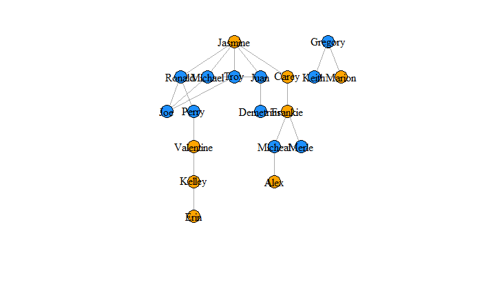

```r
# Plot the graph object g1 in a Tree layout
m <-layout_as_tree(g1)
plot(g1, vertex.label.color = "black", layout = m)
```

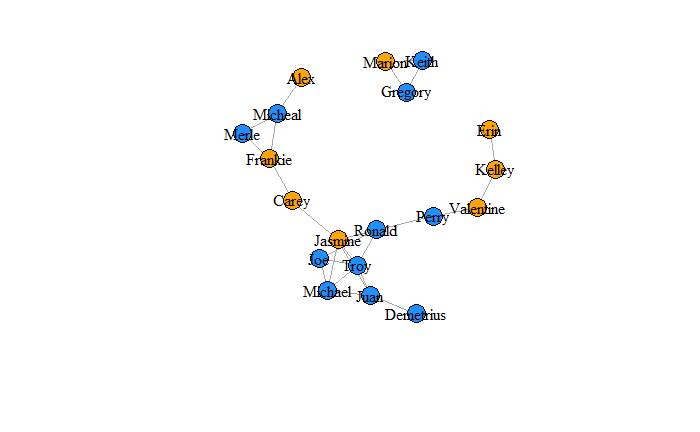

```r
# Plot the graph object g1 using igraph's chosen layout
m1 <- layout_nicely(g1)
plot(g1, vertex.label.color = "black", layout = m1)
```

## Visualizing edges

In this exercise you will learn how to change the size of edges in a network based on their weight, as well as how to remove edges from a network which can sometimes be helpful in more effectively visualizing large and highly clustered networks. In this introductory chapter, we have just scratched the surface of what’s possible in visualizing `igraph` networks. You will continue to develop these skills in future chapters.

**INSTRUCTIONS**

Create a vector `w1` of edge weights based on the number of hours friends spend together.

Plot the network ensuring that the `edge.width` is set to the vector of weights you just created. Using `edge.color = 'black'` ensures that all edges will be black.

Next, create a new graph object `g2` that is the `g1` network but with all edges of that are of weight less than two hours removed. This is done by using `delete_edges()` which takes two arguments. The first is the graph object and the second is the subset of edges to be removed. In this case, you will remove any edges that have a value of less than two hours.

Finally, plot the new network `g2` using the appropriate vector of edge widths and layout.

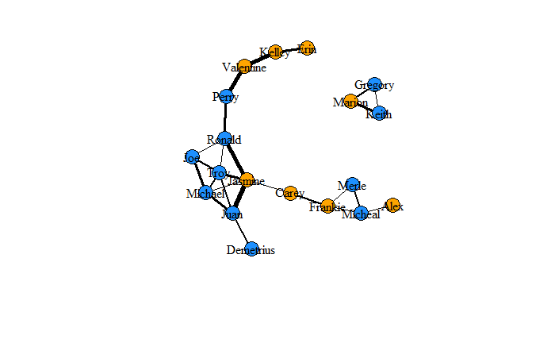

```r
library(igraph)
# Create a vector of weights based on the number of hours each pair spend together
w1 <- E(g1)$hours
# Plot the network varying edges by weights
m1 <- layout_nicely(g1)
plot(g1,
        vertex.label.color = "black",
        edge.color = 'black',
        edge.width = w1,
        layout = m1)
```

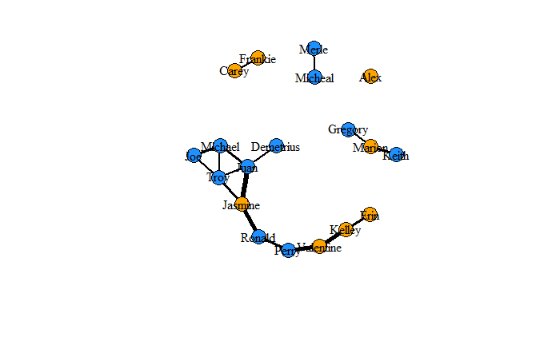

```r
# Create a new igraph object only including edges from the original graph that are greater than 2 hours long
g2 <- delete_edges(g1, E(g1)[hours < 2])
# Plot the new graph
w2 <- E(g2)$hours
m2 <- layout_nicely(g2)
plot(g2,
     vertex.label.color = "black",
     edge.color = 'black',
     edge.width = w2,
     layout = m2)
```

## Quiz on igraph objects

How many edges does Jasmine have in the network g1?

Possible Answers (Correct answer is **Bolded**)

- 1
- 3
- **5**
- 7

```r
#NOTE FROM NEIL: To solve this problem, use the following code:
# Find all edges that include "Jasmine"
#E(g1)[[inc('Jasmine')]]  # <- This Code!
```

# Chapter 2: Identifying important vertices in a network

In this chapter you will learn about directed networks. You will also learn how to identify key relationships between vertices in a network as well as how to use these relationships to identify important or influential vertices. Throughout this chapter you will use a network of measles transmission. The data come from the German city of Hagelloch in 1861. Each directed edge of the network indicates a child becoming infected with measles after coming into contact with an infected child.

## Directed igraph objects

In this exercise you will learn how to create a directed graph from a dataframe, how to inspect whether a graph object is directed and/or weighted and how to extract those vertices at the beginnning and end of directed edges.

**Instructions**

Convert the dataframe `measles` into an igraph graph object using the function `graph_from_data_frame()` and ensure that it will be a directed graph by setting the second argument to `TRUE`.

Check if the graph object is directed by using `is.directed()` . Examine whether the edges of the graph object are already weighted by using `is.weighted()`.

Subset each vertex from which each edge originates by using `head_of()`. This function takes two arguments, the first being the graph object and the second the edges to examine. For all edges you can use `E(g)`.

```r
library(igraph)
# Get the graph object
g <- graph_from_data_frame(measles, directed = TRUE)
# is the graph directed?
is.directed(g)
```

```
[1] TRUE
```

```r
# Is the graph weighted?
is.weighted(g)
```

```
[1] FALSE
```

```r
# Where does each edge originate from?
table(head_of(g, E(g)))
```

```
  1   2   3   4   5   6   7   8   9  10  11  12  13  14  15  17  18  19  20  21  22  23  24  25  26  27  28  29  30  31  32  33  34  35  36  37  38
  1   1   1   1   1   1   1   1   1   1   1   1   1   1   1   1   1   1   1   1   1   1   1   1   1   1   1   1   1   1   1   1   1   1   1   1   1
 39  40  41  42  43  44  45  46  47  48  49  50  51  52  53  54  55  56  57  58  61  62  63  64  65  66  67  68  69  70  71  72  73  74  75  76  77
  1   1   1   1   1   1   1   1   1   1   1   1   1   1   1   1   1   1   1   1   1   1   1   1   1   1   1   1   1   1   1   1   1   1   1   1   1
 78  79  80  81  82  83  84  85  86  87  88  89  90  91  92  93  94  95  96  97  98  99 100 101 102 103 104 105 106 107 108 109 110 111 112 113 114
  1   1   1   1   1   1   1   1   1   1   1   1   1   1   1   1   1   1   1   1   1   1   1   1   1   1   1   1   1   1   1   1   1   1   1   1   1
115 116 117 118 119 120 121 122 123 124 125 126 127 128 129 130 131 132 133 134 135 136 137 138 139 140 141 142 143 144 145 146 147 148 149 150 151
  1   1   1   1   1   1   1   1   1   1   1   1   1   1   1   1   1   1   1   1   1   1   1   1   1   1   1   1   1   1   1   1   1   1   1   1   1
152 153 154 155 156 157 158 159 160 161 162 163 164 165 166 167 168 169 170 171 172 173 174 175 176 177 178 179 180 181 182 183 184 185 186 187
  1   1   1   1   1   1   1   1   1   1   1   1   1   1   1   1   1   1   1   1   1   1   1   1   1   1   1   1   1   1   1   1   1   1   1   1
```

## Identifying edges for each vertex

In this exercise you will learn how to identify particular edges. You will learn how to determine if an edge exists between two vertices as well as finding all vertices connected in either direction to a given vertex.

**INSTRUCTIONS**

First make a visualization of this network using `plot()`. You will improve this visualization later. It can be useful to visualize the network before analysis. To improve visibility of the plot of this network, you should make the vertex size equal to `0` and the edge arrow size equal to `0.1`.

Check if there is an edge going in each direction between vertex 184 to vertex 178 using single brackets subsetting of the graph object. If a 1 is returned that indicates `TRUE` there is an edge. If a 0 is returned that indicates `FALSE` there is not an edge.

Using the function `incident()` identify those edges that go in either direction from vertex 184 or only those going out from vertex 184. The first argument should be the graph object, the second should be the vertex to examine and the third argument the `mode` indicating the direction. Choose from `all`, `in` and `out`.

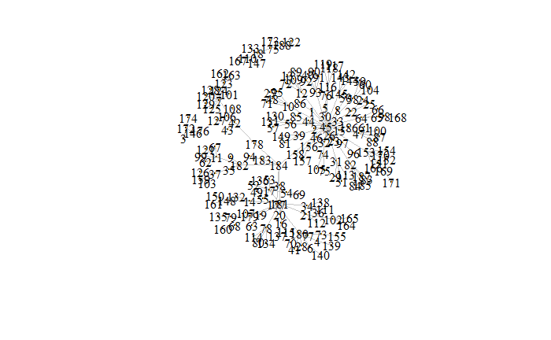

```r
library(igraph)
# Make a basic plot
plot(g,
     vertex.label.color = "black",
     edge.color = 'gray77',
     vertex.size = 0,
     edge.arrow.size = 0.1,
     layout = layout_nicely(g))
```

```r
# Is there an edge going from vertex 184 to vertex 178?
g['184', '178']
```

```
[1] 1
```

```r
# Is there an edge going from vertex 178 to vertex 184?
g['178', '184']
```

```
[1] 0
```

```r
# Show all edges going to or from vertex 184
incident(g, '184', mode = c("all"))
```

```
+ 6/184 edges from 5982b6b (vertex names):
[1] 184->45  184->182 184->181 184->178 184->183 184->177
```

```r
# Show all edges going out from vertex 184
incident(g, '184', mode = c("out"))
```

```
+ 6/184 edges from 5982b6b (vertex names):
[1] 184->45  184->182 184->181 184->178 184->183 184->177
```

## Neighbors

Often in network analysis it is important to explore the patterning of connections that exist between vertices. One way is to identify neighboring vertices of each vertex. You can then determine which neighboring vertices are shared even by unconnected vertices indicating how two vertices may have an indirect relationship through others. In this exercise you will learn how to identify neighbors and shared neighbors between pairs of vertices.

**Instructions**

Using the function `neighbors()` identify the vertices that are connected in any manner to vertex 12, those vertices that direct an edge to vertex 12 and those vertices that receive a directed edge from vertex 12. This can be achieved by choosing the correct value in the argument `mode`. Choose from `all`, `in` and `out`.

Determine if vertices 42 and 124 have a neighbor in common. Create a vector `n1` of those vertices that receive an edge from vertex 42 and a vector `n2` of those vertices that direct an edge to vertex 124 using `neighbors()`. Next use `intersection()` to identify if there are any vertices that exist in both `n1` and `n2`.

```r
library(igraph)
# Identify all neighbors of vertex 12 regardless of direction
neighbors(g, '12', mode = c('all'))
```

```
+ 5/187 vertices, named, from 5982b6b:
[1] 45  13  72  89  109
```

```r
# Identify other vertices that direct edges towards vertex 12
neighbors(g, '12', mode = c('in'))
```

```
+ 1/187 vertex, named, from 5982b6b:
[1] 45
```

```r
# Identify any vertices that receive an edge from vertex 42 and direct an edge to vertex 124
n1 <- neighbors(g, '42', mode = c('out'))
n2 <- neighbors(g, '124', mode = c('in'))
intersection(n1, n2)
```

```
+ 1/187 vertex, named, from 5982b6b:
[1] 7
```

## Distances between vertices

The inter-connectivity of a network can be assessed by examining the number and length of paths between vertices. A path is simply the chain of connections between vertices. The number of intervening edges between two vertices represents the geodesic distance between vertices. Vertices that are connected to each other have a geodesic distance of 1. Those that share a neighbor in common but are not connected to each other have a geodesic distance of 2 and so on. In directed networks, the direction of edges can be taken into account. If two vertices cannot be reached via following directed edges they are given a geodesic distance of infinity. In this exercise you will learn how to find the longest paths between vertices in a network and how to discern those vertices that are within nn connections of a given vertex. For disease transmission networks such as the measles dataset this helps you to identify how quickly the disease spreads through the network.

**INSTRUCTIONS**

Find the length of the longest path in the network using `farthest_vertices()`.

Identify the sequence of the path using `get_diameter()`. This demonstrates the individual children that passed the disease the furthest through the network.

Use `ego()` to find all vertices that are reachable within 2 connections of vertex 42 and then those that can reach vertex 42 within two connections. The first argument of `ego()` is the graph object, the second argument is the maximum number of connections between the vertices, the third argument is the vertex of interest, and the fourth argument determines if you are considering connections going out or into the vertex of interest.

```r
library(igraph)
# Which two vertices are the furthest apart in the graph ?
farthest_vertices(g)
```

```
$vertices
+ 2/187 vertices, named, from 5982b6b:
[1] 184 162

$distance
[1] 5
```

```r
# Shows the path sequence between two furthest apart vertices.
get_diameter(g)
```

```
+ 6/187 vertices, named, from 5982b6b:
[1] 184 178 42  7   123 162
```

```r
# Identify vertices that are reachable within two connections from vertex 42
ego(g, 2, '42', mode = c('out'))
```

```
[[1]]
+ 13/187 vertices, named, from 5982b6b:
 [1] 42  7   106 43  123 101 120 124 125 128 129 108 127
```

```r
# Identify vertices that can reach vertex 42 within two connections
ego(g, 2, '42', mode = c('in'))
```

```
[[1]]
+ 3/187 vertices, named, from 5982b6b:
[1] 42  178 184
```

## Quiz

**Finding longest path between two vertices**

What is the longest possible path in a network referred to as? (Answer is **Bolded**)

Possible Answers

Weight

Geodesic distance

Degree

**Diameter**

## Identifying key vertices

Perhaps the most straightforward measure of vertex importance is the degree of a vertex. The out-degree of a vertex is the number of other individuals to which a vertex has an outgoing edge directed to. The in-degree is the number of edges received from other individuals. In the measles network, individuals that infect many other individuals will have a high out-degree. In this exercise you will identify whether indviduals infect equivalent amount of other children or if there are key children who have high out-degrees and infect many other children.

**INSTRUCTIONS** Calculate the out-degree of each vertex using the function `degree()`. The first argument is the network graph object and the second argument is the `mode` which should be one of `out`, `in` or `all`. Assign the output of this function to the object `g.outd`.

View a summary of the out-degrees of all individuals using the function `table()` on the vector object `g.outd`.

Make a histogram of the out-degrees using the function `hist()` on the vector object `g.outd`.

Determine which vertex has the highest out-degree in the network using the function `which.max()` on the vector object `g.outd`.

```r
library(igraph)
# Calculate the out-degree of each vertex
g.outd <- degree(g, mode = c("out"))
# View a summary of out-degree
table(g.outd)
```

```
g.outd
  0   1   2   3   4   6   7   8  30
125  21  16  12   6   2   3   1   1
```

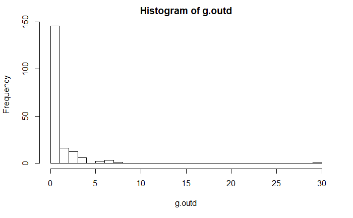

```r
# Make a histogram of out-degrees
hist(g.outd, breaks = 30)
```

```r
# Find the vertex that has the maximum out-degree
which.max(g.outd)
```

```
45
 1
```

## Betweenness

Another measure of the importance of a given vertex is its betweenness. This is an index of how frequently the vertex lies on shortest paths between any two vertices in the network. It can be thought of as how critical the vertex is to the flow of information through a network. Individuals with high betweenness are key bridges between different parts of a network. In our measles transmission network, vertices with high betweenness are those children who were central to passing on the disease to other parts of the network. In this exercise, you will identify the betweenness score for each vertex and then make a new plot of the network adjusting the vertex size by its betweenness score to highlight these key vertices.

**INSTRUCTIONS**

Calculate the betweenness of each vertex using the function `betweenness()` on the graph object `g`. Ensure that the scores are calculated for a directed network. The results of this function will be assigned as `g.b`.

Visually examine the distribution of betweenness scores using the function `hist()`.

Use `plot()` to make a plot of the network based on betweenness scores. The vertex labels should be made `NA` so that they do not appear. The vertex size attribute should be one plus the square-root of the betweenness scores that are in object `g.b`. Given the huge disparity in betweenness scores in this network, normalizing the scores in this manner ensures that all nodes can be viewed but their relative importance is still identifiable.

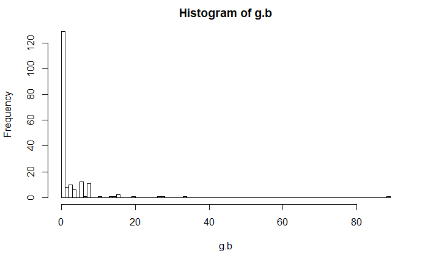

```r
library(igraph)
# Calculate betweenness of each vertex
g.b <- betweenness(g, directed = TRUE)
# Show histogram of vertex betweenness
hist(g.b, breaks = 80)
```

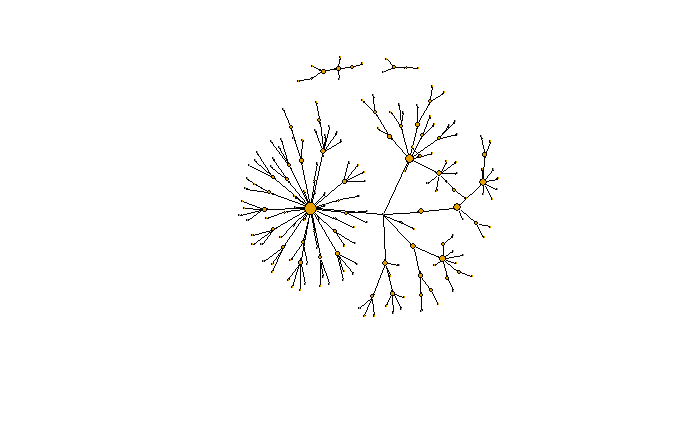

```r
# Create plot with vertex size determined by betweenness score
plot(g,
     vertex.label = NA,
     edge.color = 'black',
     vertex.size = sqrt(g.b)+1,
     edge.arrow.size = 0.05,
     layout = layout_nicely(g))
```

## Visualizing important nodes and edges

One issue with the measles dataset is that there are three individuals for whom no information is known about who infected them. One of these individuals (vertex 184) appears ultimately responsible for spreading the disease to many other individuals even though they did not directly infect too many indviduals. However, because vertex 184 has no incoming edge in the network they appear to have low betweenness. One way it is possible to explore the importance of this vertex is by visualizing the geodesic distances of connections going out from this individual. In this exercise you shall create a plot of these distances from this patient zero.

**INSTRUCTIONS**

Use `make_ego_graph()` to create a subset of our network comprised of vertices that are connected to vertex 184. The first argument is the original graph `g`. The second argument is the maximal number of connections that any vertex needs to be connected to our vertex of interest. In this case we can use `diameter()` to return the length of the longest path in the network. The third argument is our vertex of interest which should be 184. The final argument is the mode. In this instance you can include all connections regardless of direction.

Create an object `dists` that contains the geodesic distance of every vertex from vertex 184. Use the function `distances()` to calculate this.

Assign the attribute `color` to each vertex. Each color will be selected based on its geodesic distance. The color palette `colors` is a length equal to the maximal geodesic distance plus one. This is so that vertices of the same distance are plotted in the same color and patient zero also has its own color.

Use `plot()` to visualize the network `g184`. The vertex label should be the geodesic distances `dists`.

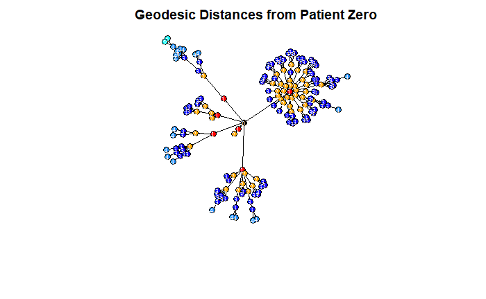

```r
# Make an ego graph
g184 <- make_ego_graph(g, diameter(g), nodes = '184', mode = c("all"))[[1]]
# Get a vector of geodesic distances of all vertices from vertex 184
dists <- distances(g184, "184")
# Create a color palette of length equal to the maximal geodesic distance plus one.
colors <- c("black", "red", "orange", "blue", "dodgerblue", "cyan")
# Set color attribute to vertices of network g184.
V(g184)$color <- colors[dists+1]
# Visualize the network based on geodesic distance from vertex 184 (patient zero).
plot(g184,
     vertex.label = dists,
     vertex.label.color = "white",
     vertex.label.cex = .6,
     edge.color = 'black',
     vertex.size = 7,
     edge.arrow.size = .05,
     main = "Geodesic Distances from Patient Zero"
     )
```

### Important Vertices Quiz

Which measure of a vertex importance is determined by how often that vertex lies on the shortest path between any two vertices in a network? (Answer is **Bolded**)

**Betweenness**

Degree

Diameter

Weight

# Chapter 3: Characterizing network structures

This module will show how to characterize global network structures and sub-structures. It will also introduce generating random network graphs.

## Forrest Gump network

In this chapter you will use a social network based on the movie Forrest Gump. Each edge of the network indicates that those two characters were in at least one scene of the movie together. Therefore this network is undirected. To familiarize yourself with the network, you will first create the network object from the raw dataset. Then, you will identify key vertices using a measure called eigenvector centrality. Individuals with high eigenvector centrality are those that are highly connected to other highly connected individuals. You will then make an exploratory visualization of the network.

**INSTRUCTIONS**

Inspect the first few rows of the dataframe `gump` using `head()`.

Make an undirected network using `graph_from_data_frame()`. Identify the key vertices using the function `eigen_centrality()` and assign the results of this to the object `g.ec`. Next identify which individual has the highest eigenvector centrality using `which.max()`. The values of the centrality scores are stored in `g.ec$vector`.

Make a plot of the Forrest Gump Network using `plot()`. Make the size of the vertices equal to 25 times the eigenvector centrality values that are stored in `g.ec$vector`.

```r
library(igraph)
# Inspect Forrest Gump Movie dataset
head(gump)
```

| V1 | V2 |
| --- | --- |
| ABBIE HOFFMAN | JENNY |
| ABBIE HOFFMAN | POLICEMAN |
| ANCHORMAN | FORREST |
| ANCHORMAN | LT DAN |
| ANCHORMAN | MARGO |
| ANCHORMAN | MRS GUMP |

```r
# Make an undirected network
g <- graph_from_data_frame(gump, directed = FALSE)
# Identify key nodes using eigenvector centrality
g.ec <- eigen_centrality(g)
which.max(g.ec$vector)
```

```
FORREST
     36
```

[figure not shown]

```r
# Plot Forrest Gump Network
plot(g,
vertex.label.color = "black",
vertex.label.cex = 0.6,
vertex.size = 25*(g.ec$vector),
edge.color = 'gray88',
main = "Forrest Gump Network"
)
```

## Network density and average path length

The first graph level metric you will explore is the density of a graph. This is essentially the proportion of all potential edges between vertices that actually exist in the network graph. It is an indicator of how well connected the vertices of the graph are.

Another measure of how interconnected a network is average path length. This is calculated by determining the mean of the lengths of the shortest paths between all pairs of vertices in the network. The longest path length between any pair of vertices is called the diameter of the network graph. You will calculate the diameter and average path length of the original graph `g`.

**INSTRUCTIONS**

Using the function `edge_density()` calculate the density of the graph `g` and assign this value to the vector `gd`.

Use `diameter()` to calculate the diameter of the original graph `g`.

Assign the average path length of g to `g.apl` with the function `mean_distance()`.

```r
library(igraph)
# Get density of a graph
gd <- edge_density(g)
# Get the diameter of the graph g
diameter(g, directed = FALSE)
```

```
[1] 4
```

```r
# Get the average path length of the graph g
g.apl <- mean_distance(g, directed = FALSE)
g.apl
```

```
[1] 1.994967
```

### Graph density quiz

If a graph has 7 vertices there are 21 possible edges in the network. If 14 edges exist, what is the density of the network? (Answer is **Bolded**)

0

0.5

**0.67**

1

## Random graphs

Generating random graphs is an important method for investigating how likely or unlikely other network metrics are likely to occur given certain properties of the original graph. The simplest random graph is one that has the same number of vertices as your original graph and approximately the same density as the original graph. Here you will create one random graph that is based on the original Forrest Gump Network.

**INSTRUCTIONS**

Generate a random graph using the function `erdos.renyi.game()`. The first argument `n` should be the number of nodes of the graph `g` which can be calculated using `gorder()`, the second argument `p.or.m` should be the density of the graph `g` which you previously stored as the obejct `gd`. The final argument is set as `type='gnp'` to tell the function that you are using the density of the graph to generate a random graph. Store this new graph as the vector `g.random`.

Get the density of the random graph `g.random`. You will notice if you generate a random graph a few times that this value will slightly vary but be approximately equal to the density of your original graph `g` from the previous exercise stored in the object `gd`.

Calculate the average path length of the random graph `g.random`.

```r
library(igraph)
# Create one random graph with the same number of nodes and edges as g
g.random <- erdos.renyi.game(n = gorder(g), p.or.m = gd, type = "gnp")
g.random
```

```
IGRAPH 6323aee U--- 94 263 -- Erdos renyi (gnp) graph
+ attr: name (g/c), type (g/c), loops (g/l), p (g/n)
+ edges from 6323aee:
  [1]  2-- 3  4-- 6 10--11  8--15  3--16  8--16  5--20 11--20 12--20 18--20  2--22 15--22  4--23  7--23 19--24 10--25  4--26  8--26 16--26 19--26
 [21] 24--26 18--27 24--27 11--29 17--29  9--30 20--30 25--30  6--31 10--32 11--32 28--32 11--33 15--33  9--35 26--35 33--35 19--36  1--37 29--37
 [41] 36--37 12--38 17--38 32--38 23--39 39--41  3--42 14--42 22--42 25--42  2--43 29--43 31--43 37--43 39--43  4--44 43--44  2--45 16--45 32--45
 [61] 10--46 30--46  6--47  8--47 28--48 29--48 24--49 28--49 30--50 38--50  3--51  4--51 19--51 25--51 26--51 39--51 49--52 39--54 43--54  1--55
 [81] 17--55 29--55 46--55 52--55 53--55 14--56 35--56 45--56 13--57 24--57 29--57 32--58 55--58  7--59 28--59 32--59 34--59 48--59  2--60  8--60
[101] 10--60 21--60 47--60 49--60 54--60 28--61 32--61 34--61 44--61  5--62 13--62 19--62 20--62  3--63 16--63 18--63 34--63  1--64 13--64 50--64
[121]  4--65 56--65 61--65  8--66 15--66 59--66 48--67 50--67 51--67 64--67 21--68 28--68 31--68 37--68 39--68 67--68  5--69 38--69 61--69 68--69
[141]  5--70 60--70 14--71 18--71 23--71 38--71 44--71  3--72  4--72 19--72 36--72 45--72 46--72 67--72 32--73 25--74 64--74 67--74  3--75 25--75
+ ... omitted several edges
```

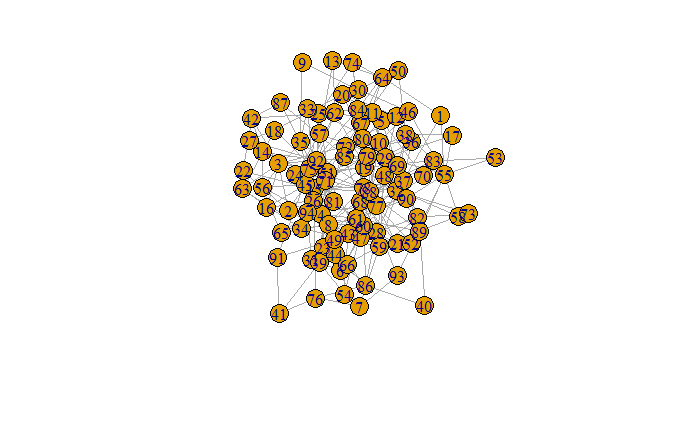

```r
plot(g.random)
```

```r
# Get density of new random graph `g.random`
edge_density(g.random)
```

```
[1] 0.0601693
```

```r
#Get the average path length of the random graph g.random
mean_distance(g.random, directed = FALSE)
```

```
[1] 2.808968
```

## Network randomizations

In the previous exercise you may have noticed that the average path length of the Forrest Gump network was smaller than the average path length of the random network. If you ran the code a few times you will have noticed that it is nearly always lower in the Forrest Gump network than the random network. What this suggests is that the Forrest Gump network is more highly interconnected than each random network even though the random networks have the same number of vertices and approximately identical graph densities. Rather than re-running this code many times, you can more formally address this by creating 1000 random graphs based on the number of vertices and density of the original Forrest Gump graph. Then, you can see how many times the average path length of the random graphs is less than the original Forrest Gump network. This is called a randomization test.

**INSTRUCTIONS**

Generate 1000 random graphs of the original graph `g` by executing the code that creates the list object `gl` and the for loop.

Calculate the average path length of the 1000 random graphs using `lapply()`. Create a vector `gl.apls` of these 1000 values by executing the code that uses `unlist()`.

Plot a histogram of the average path lengths of the 1000 random graphs using `hist()` on the vector `gl.apls`. Add a red dashed line to the plot using abline() with the x-intercept being the value of the average path length of the original graph `g.apl`. You calculated this value in the previous exercise.

Calculate the proportion of times that the values of the average path length of random graphs `gl.apls` are lower than the value of the original graph `g.apl`. This is essentially the probability that we would expect our observed average path length by chance given the original density and number of vertices of the original graph.

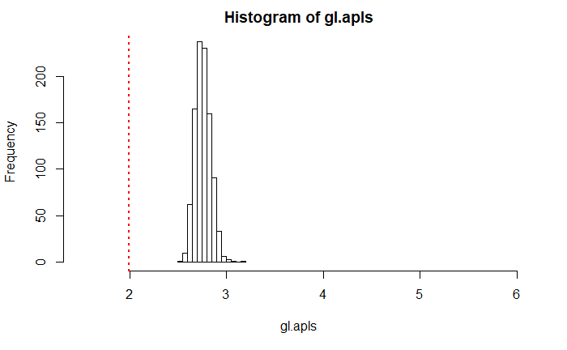

```r
library(igraph)
# Generate 1000 random graphs
gl <- vector('list', 1000)

for(i in 1:1000){
gl[[i]] <- erdos.renyi.game(n = gorder(g), p.or.m = gd, type = "gnp")
}
# Calculate average path length of 1000 random graphs
gl.apl <- lapply(gl, mean_distance, directed = FALSE)
gl.apls <- unlist(gl.apl)
# Plot the distribution of average path lengths
hist(gl.apls, xlim = range(c(1.5, 6)))
abline(v = g.apl, col = "red", lty = 3, lwd=2)
```

```r
# Calculate the proportion of graphs with an average path length lower than our observed
sum(gl.apls < g.apl)/1000
```

```
[1] 0
```

### Randomization quiz

Randomization tests enable you to identify:

Possible Answers (Correct Answer is **Bolded**)

The density of a network.

The number of vertices in a network.

The number of edges in a network.

**Whether features of your original network are particularly unusual**

## Triangles and transitivity

Another important measure of local connectivity in a network graph involves investigating triangles (also known as triads). In this exercise you will find all closed triangles that exist in a network. This means that an edge exists between three given vertices. You can then calculate the transitivity of the network. This is equivalent to the proportion of all possible triangles in the network that are closed. You will also learn how to identify the number of closed triangles that any given vertex is a part of and its local transitivity - that is, the proportion of closed triangles that the vertex is a part of given the theoretical number of triangles it could be a part of.

**INSTRUCTIONS**

Show a matrix of all possible triangles in the Forrest Gump network `g` using the function `triangles()`.

Using the function `count_triangles()`, find how many triangles that the vertex `"BUBBA"` is a part of. The `vids` argument refers to the id of the vertex.

Calculate the global transitivity of the network `g` using `transitivity()`.

Find the local transitivity of vertex `"BUBBA"` also using the function `transitivity()`. The type is defined as `local` to indicate that you are calculating a local rather than global transitivity.

```r
library(igraph)
# Show all triangles in the network.
matrix(triangles(g), nrow = 3)
```

```
     [,1] [,2] [,3] [,4] [,5] [,6] [,7] [,8] [,9] [,10] [,11] [,12] [,13] [,14] [,15] [,16] [,17] [,18] [,19] [,20] [,21] [,22] [,23] [,24] [,25]
[1,]   36   36   36   36   36   36   36   36   36    36    36    36    36    36    36    36    36    36    36    36    36    36    36    36    36
[2,]    1    1    1    1    2    4    4    6    6     6     6     7     7     8    11    11    11    12    12    13    14    14    14    14    14
     [,26] [,27] [,28] [,29] [,30] [,31] [,32] [,33] [,34] [,35] [,36] [,37] [,38] [,39] [,40] [,41] [,42] [,43] [,44] [,45] [,46] [,47] [,48] [,49]
[1,]    36    36    36    36    36    36    36    36    36    36    36    36    36    36    36    36    36    36    36    36    36    36    36    36
[2,]    14    14    14    14    15    15    17    17    18    18    19    19    21    22    24    26    26    26    26    26    26    27    27    27
     [,50] [,51] [,52] [,53] [,54] [,55] [,56] [,57] [,58] [,59] [,60] [,61] [,62] [,63] [,64] [,65] [,66] [,67] [,68] [,69] [,70] [,71] [,72] [,73]
[1,]    36    36    36    36    36    36    36    36    36    36    36    36    36    36    36    36    36    36    36    36    36    36    36    36
[2,]    28    28    30    30    30    34    38    38    38    39    39    40    40    41    41    41    41    41    41    41    41    41    41    41
     [,74] [,75] [,76] [,77] [,78] [,79] [,80] [,81] [,82] [,83] [,84] [,85] [,86] [,87] [,88] [,89] [,90] [,91] [,92] [,93] [,94] [,95] [,96] [,97]
[1,]    36    36    36    36    36    36    36    36    36    36    36    36    36    36    36    36    36    36    36    36    36    36    36    36
[2,]    41    41    41    41    41    41    41    41    41    41    41    41    41    41    41    41    41    41    41    41    41    41    41    41
     [,98] [,99] [,100] [,101] [,102] [,103] [,104] [,105] [,106] [,107] [,108] [,109] [,110] [,111] [,112] [,113] [,114] [,115] [,116] [,117]
[1,]    36    36     36     36     36     36     36     36     36     36     36     36     36     36     36     36     36     36     36     36
[2,]    41    41     41     41     41     41     41     43     43     43     44     44     44     44     44     44     44     44     44     44
     [,118] [,119] [,120] [,121] [,122] [,123] [,124] [,125] [,126] [,127] [,128] [,129] [,130] [,131] [,132] [,133] [,134] [,135] [,136] [,137]
[1,]     36     36     36     36     36     36     36     36     36     36     36     36     36     36     36     36     36     36     36     36
[2,]     44     44     44     44     44     44     45     47     47     47     47     47     48     48     48     48     49     49     49     50
     [,138] [,139] [,140] [,141] [,142] [,143] [,144] [,145] [,146] [,147] [,148] [,149] [,150] [,151] [,152] [,153] [,154] [,155] [,156] [,157]
[1,]     36     36     36     36     36     36     36     36     36     36     36     36     36     36     36     36     36     36     36     36
[2,]     50     51     51     52     53     54     54     56     58     59     60     60     60     60     60     60     60     61     62     62
     [,158] [,159] [,160] [,161] [,162] [,163] [,164] [,165] [,166] [,167] [,168] [,169] [,170] [,171] [,172] [,173] [,174] [,175] [,176] [,177]
[1,]     36     36     36     36     36     36     36     36     36     36     36     36     36     36     36     36     36     36     41     41
[2,]     62     62     63     64     64     64     64     64     64     65     65     65     65     65     65     65     65     66      1      1
     [,178] [,179] [,180] [,181] [,182] [,183] [,184] [,185] [,186] [,187] [,188] [,189] [,190] [,191] [,192] [,193] [,194] [,195] [,196] [,197]
[1,]     41     41     41     41     41     41     41     41     41     41     41     41     41     41     41     41     41     41     41     41
[2,]      1      1      6      6      6      6      7      7      8     11     11     11     12     12     13     26     26     26     26     26
     [,198] [,199] [,200] [,201] [,202] [,203] [,204] [,205] [,206] [,207] [,208] [,209] [,210] [,211] [,212] [,213] [,214] [,215] [,216] [,217]
[1,]     41     41     41     41     41     41     41     41     41     41     41     41     41     41     41     41     41     41     41     41
[2,]     26     27     27     27     30     30     30     38     38     38     39     39     40     40     43     43     43     44     44     44
     [,218] [,219] [,220] [,221] [,222] [,223] [,224] [,225] [,226] [,227] [,228] [,229] [,230] [,231] [,232] [,233] [,234] [,235] [,236] [,237]
[1,]     41     41     41     41     41     41     41     41     41     41     41     41     41     41     41     41     41     41     41     41
[2,]     44     45     47     47     47     47     47     48     48     48     48     49     49     49     50     50     51     51     52     53
     [,238] [,239] [,240] [,241] [,242] [,243] [,244] [,245] [,246] [,247] [,248] [,249] [,250] [,251] [,252] [,253] [,254] [,255] [,256] [,257]
[1,]     41     41     41     41     41     44     44     44     44     44     44     44     44     44     44     44     44     44     44     44
[2,]     54     58     58     61     66      2     14     14     14     14     14     14     17     17     19     19     22     43     43     53
     [,258] [,259] [,260] [,261] [,262] [,263] [,264] [,265] [,266] [,267] [,268] [,269] [,270] [,271] [,272] [,273] [,274] [,275] [,276] [,277]
[1,]     44     44     44     44     44     44     44     44     44     44     44     44     44     44     14     14     14     14     14     14
```

[output cut: 20 more lines]

```r
# Count the number of triangles that vertex "BUBBA" is in.
count_triangles(g, vids='BUBBA')
```

```
[1] 37
```

```r
# Calculate  the global transitivity of the network.
g.tr <- transitivity(g)
g.tr
```

```
[1] 0.1918082
```

```r
# Calculate the local transitivity for vertex BUBBA.
transitivity(g, vids='BUBBA', type = "local")
```

```
[1] 0.6727273
```

## Transitivity randomizations

As you did for the average path length, let’s investigate if the global transitivity of the Forrest Gump network is significantly higher than we would expect by chance for random networks of the same size and density. You can compare Forrest Gump’s global transitivity to 1000 other random networks.

**INSTRUCTIONS**

One thousand random networks are stored in the list object `gl`. Using `lapply()` and `transitivity()` calculate the global transitivity of each of these networks. Assign these results to gl.tr.

Using `unlist()` convert `gl.tr` to a numeric vector `gl.trs`.

Investigate the summary statistics of the transitivities of the random networks using `summary()`.

Calculate the proportion of random graphs that have a transitivity higher than the transitivity of Forrest Gump’s network, which you previously calculated and assigned to `g.tr`.

```r
library(igraph)
# Calculate average transitivity of 1000 random graphs
gl.tr <- lapply(gl, transitivity)
gl.trs <- unlist(gl.tr)
# Get summary statistics of transitivity scores
summary(gl.trs)
```

```
   Min. 1st Qu.  Median    Mean 3rd Qu.    Max.
0.02826 0.05430 0.06127 0.06178 0.06921 0.09912
```

```r
# Calculate the proportion of graphs with a transitivity score higher than Forrest Gump's network.
sum(gl.trs > g.tr)/1000
```

```
[1] 0
```

## Cliques

Identifying cliques is a common practice in undirected networks. In a clique every two unique nodes are adjacent - that means that every individual node is connected to every other individual node in the clique. In this exercise you will identify the largest cliques in the Forrest Gump network. You will also identify the number of maximal cliques of various sizes. A clique is maximal if it cannot be extended to a larger clique.

**INSTRUCTIONS**

Identify the largest cliques in the network using the function `largest_cliques()`.

Determine all the maximal cliques in the network using the function `max_cliques()`. Assign the output of this function to the list object `clq`.

Calculate the length of each of the maximal cliques. Use `lapply()` to loop through the object `clq` determining the `length()` of each object in the list. Then `unlist()` and use `table()` to observe how large each of the maximal cliques are.

```r
library(igraph)
# Identify the largest cliques in the network
largest_cliques(g)
```

```
[[1]]
+ 9/94 vertices, named, from 61f78d7:
[1] FORREST   STRONGARM BUBBA     DALLAS    LT DAN    MAN       SGT SIMS  SOLDIER   SONG

[[2]]
+ 9/94 vertices, named, from 61f78d7:
[1] FORREST JENNY   EMCEE   MAN #   MAN #1  MAN #2  MAN #3  MAN #5  MEN
```

```r
# Determine all maximal cliques in the network and assign to object 'clq'
clq <- max_cliques(g)
# Calculate the size of each maximal clique.
table(unlist(lapply(clq, length)))
```

```
 2  3  4  5  6  7  9
12 24  7  2  4  2  2
```

## Visualize largest cliques

Often in network visualization you will need to subset part of a network to inspect the inter-connections of particular vertices. Here, you will create a visualization of the largest cliques in the Forrest Gump network. In the last exercise you determined that there were two cliques of size 9. You will plot these side-by-side after creating two new igraph objects by subsetting out these cliques from the main network. The function `subgraph()` *Note from Neil: New version of igraph uses function called `induced_subgraph`* enables you to choose which vertices to keep in a new network object.

**INSTRUCTIONS**

Assign the list of the largest cliques in the network to the object `lc`.

Create two new undirected subgraphs using the function `subgraph()`. The first, `gs1`, should contain only the vertices in the first largest clique. The second, `gs2`, should contain only the vertices in the second largest clique. This function is wrapped in `as.undirected()` to ensure that the subgraph is also undirected.

Visualize the two largest cliques side by side using `plot()`. First execute the code: `par(mfrow=c(1,2))`. This is to ensure that the two visualizations sit side-by-side. Make sure that the layout is set to `layout.circle()` to make the visualization easier to view.

[figure not shown]

```r
library(igraph)
# Assign largest cliques output to object 'lc'
lc <- largest_cliques(g)
# Create two new undirected induced_subgraphs, each containing only the vertices of each largest clique.
gs1 <- as.undirected(induced_subgraph(g, lc[[1]]))
gs2 <- as.undirected(induced_subgraph(g, lc[[2]]))
# Plot the two largest cliques side-by-side
par(mfrow=c(1,2)) # To plot two plots side-by-side
plot(gs1,
     vertex.label.color = "black",
     vertex.label.cex = 0.9,
     vertex.size = 0,
     edge.color = 'gray28',
     main = "Largest Clique 1",
     layout = layout.circle(gs1)
)
plot(gs2,
     vertex.label.color = "black",
     vertex.label.cex = 0.9,
     vertex.size = 0,
     edge.color = 'gray28',
     main = "Largest Clique 2",
     layout = layout.circle(gs2)
)
```

# Chapter 4: Identifying special relationships

This chapter will further explore the partitioning of networks into sub-networks and determining which vertices are more highly related to one another than others. You will also develop visualization methods by creating three-dimensional visualizations.

## Assortativity

In this exercise you will determine the `assorativity()` of the second friendship network from the first chapter. This is a measure of how preferentially attached vertices are to other vertices with identical attributes. You will also determine the degree assortativity which determines how preferentially attached are vertices to other vertices of a similar degree.

**INSTRUCTIONS**

Make an exploratory plot of the friendship network object g1 using `plot()`.

Convert the gender attribute of each vertex to a vector of numbers called `values` by factorizing and then using `as.numeric()`.

Calculate the assortativity based on gender by using the function `assortativity()`. The first argument should be the graph object `g1`. The second argument are the `values`.

Calculate the degree assortativity of the network using `assortativity.degree()`. The first argument should be the graph object.

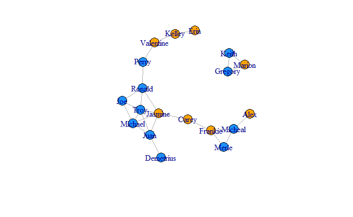

```r
# Plot the network
plot(g1)
```

```r
# Convert the gender attribute into a numeric value
values <- as.numeric(factor(V(g1)$gender))
# Calculate the assortativity of the network based on gender
assortativity(g1, values)
```

```
[1] 0.1319444
```

```r
# Calculate the assortativity degree of the network
assortativity.degree(g1, directed = FALSE)
```

```
[1] 0.4615385
```

## Using randomizations to assess assortativity

In this exercise you will determine how likely the observed assortativity in the friendship network is given the genders of vertices by performing a randomization procedure. You will randomly permute the gender of vertices in the network 1000 times and recalculate the assortativity for each random network.

**INSTRUCTIONS**

Use `assortativity()` to calculate the assortativity of the graph object `g1` based on gender using the object `values` calculated in the previous exercise, and assign this to the object `observed.assortativity`.

Inside the for loop calculate the assortativity of the network `g1` using `assortativity()` while randomly permuting the object values each time with `sample()`.

Plot the distribution of assortativity values from this permutation procedure using `hist()` and add a red vertical line for the original `g1` network observed assortativity value that is stored in `observed.assortativity`.

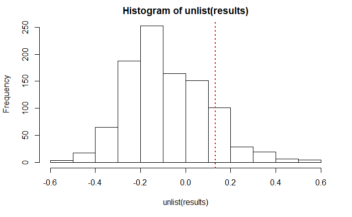

```r
# Calculate the observed assortativity
observed.assortativity <- assortativity(g1, values)
# Calculate the assortativity of the network randomizing the gender attribute 1000 times
results <- vector('list', 1000)
for(i in 1:1000){
  results[[i]] <- assortativity(g1, sample(values))
}
# Plot the distribution of assortativity values and add a red vertical line at the original observed value
hist(unlist(results))
abline(v = observed.assortativity, col = "red", lty = 3, lwd=2)
```

## Reciprocity

The reciprocity of a directed network reflects the proportion of edges that are symmetrical. That is, the proportion of outgoing edges that also have an incoming edge. It is commonly used to determine how inter-connected directed networks are. An example of a such a network may be grooming exchanges in chimpanzees. Certain chimps may groom another but do not get groomed by that individual, whereas other chimps may both groom each other and so would have a reciprocal tie.

**INSTRUCTIONS**

In this example network of chimps grooming each other, make an exploratory plot of the network g using `plot()`. Make the arrow size 0.3 using the argument edge.arrow.size and the arrow width 0.5 using the argument `edge.arrow.width`.

Calculate the reciprocity of the graph using `reciprocity()`.

## Reciprocity

The reciprocity of a directed network reflects the proportion of edges that are symmetrical. That is, the proportion of outgoing edges that also have an incoming edge. It is commonly used to determine how inter-connected directed networks are. An example of a such a network may be grooming exchanges in chimpanzees. Certain chimps may groom another but do not get groomed by that individual, whereas other chimps may both groom each other and so would have a reciprocal tie.

**INSTRUCTIONS**

In this example network of chimps grooming each other, make an exploratory plot of the network g using `plot()`. Make the arrow size 0.3 using the argument `edge.arrow.size` and the arrow width 0.5 using the argument `edge.arrow.width`.

Calculate the reciprocity of the graph using `reciprocity()`.

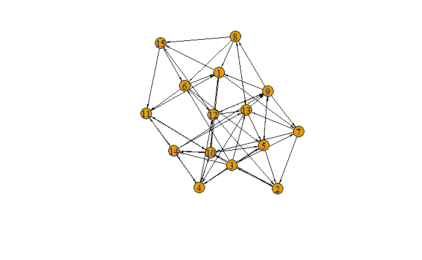

```r
library(igraph)
# Make a plot of the chimp grooming network
plot(g,
     edge.color = "black",
     edge.arrow.size = 0.3,
     edge.arrow.width = 0.5)
```

```r
# Calculate the reciprocity of the graph
reciprocity(g)
```

```
[1] 0.2711864
```

## Assortativity quiz

What does assortativity measure? (Answer is **Bolded**)

How far apart two vertices are.

How important a vertex is.

**How likely vertices are to connect to others that share some attribute in common.**

How dense a network is.

## Fast-greedy community detection

The first community detection method you will try is fast-greedy community detection. You will use the Zachary Karate Club network. This social network contains 34 club members and 78 edges. Each edge indicates that those two club members interacted outside the karate club as well as at the club. Using this network you will determine how many sub-communities the network has and which club members belong to which subgroups. You will also plot the networks by community membership.

**Instructions**

Use the function `fastgreedy.community()` to create a community object. Assign this to the object `kc`.

Use the function `sizes()` on `kc` to determine how many communities were detected and how many club members are in each.

Display which club members are in which community using the function `membership()`.

Make the default community plot by using the function `plot()`. The first argument should be the object `kc` and the second argument is the graph object `g`.

```r
g <- graph.edgelist(kc, directed = FALSE)
# Perform fast-greedy community detection on network graph
kc = fastgreedy.community(g)
# Determine sizes of each community
sizes(kc)
```

```
Community sizes
 1  2  3
 8 17  9
```

```r
# Determine which individuals belong to which community
membership(kc)
```

```
 [1] 1 3 3 3 1 1 1 3 2 3 1 1 3 3 2 2 1 3 2 1 2 3 2 2 2 2 2 2 2 2 2 2 2 2
```

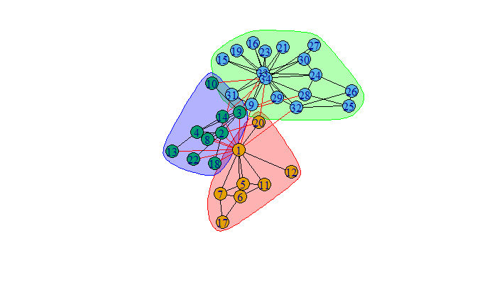

```r
# Plot the community structure of the network
plot(kc, g)
```

## Edge-betweenness community detection

An alternative community detection method is edge-betweenness. In this exercise you will repeat the community detection of the karate club using this method and compare the results visually to the fast-greedy method.

**INSTRUCTIONS** Use the function `edge.betweenness.community()` on the graph object `g` to create the community `igraph` object `gc`.

Calculate the size and number of communities by using the function `sizes` on the community `igraph` object.

Plot each community plot next to each other using `par()`. The first plot should include the community object `kc` from the previous exercise. The second plot should include the community object `gc`.

```r
# Perform edge-betweenness community detection on network graph
gc = edge.betweenness.community(g)
# Determine sizes of each community
sizes(gc)
```

```
Community sizes
 1  2  3  4  5
10  6  5 12  1
```

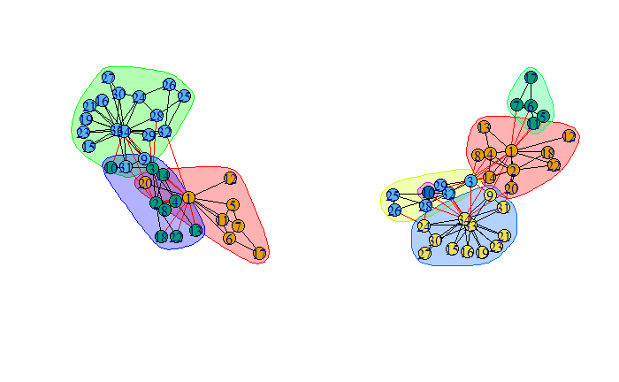

```r
# Plot community networks determined by fast-greedy and edge-betweenness methods side-by-side
par(mfrow = c(1, 2))
plot(kc, g)
plot(gc, g)
```

## Community quiz

`igraph` has many community detection algorithms. How many communities does the algorithm `leading.eigenvector.community()` believe that the karate club network object `g` can be assigned to?

```r
leading.eigenvector.community(g)
```

```
IGRAPH clustering leading eigenvector, groups: 4, mod: 0.39
+ groups:
  $`1`
  [1]  1  5  6  7 11 12 17

  $`2`
   [1]  9 10 15 16 19 21 23 27 30 31 33 34

  $`3`
  [1]  2  3  4  8 13 14 18 20 22

  $`4`
  + ... omitted several groups/vertices
```

Possible Answers (Correct answer is **Bolded**)

1

2

3

**4**

## Note from Neil Regarding the below Interactive network sections

Unfortunately as of 03/07/18 the `threejs` package does not properly render to rStudio or R-notebooks in general. The edge lines will not appear properly. To properly view the threejs plots (using function graphjs()) you need to plot it in your console, to view it in the viewer window, and show it in a new window. This will open it up in an html document and the edges will properly show. If you find this package ever begins to work please email me to let me know! at ndyetz@gmail.com!

## Interactive networks with threejs

In this course you have exclusively used `igraph` to make basic static network plots. There are many packages available to make network plots. One very useful one is `threejs` which allows you to make interactive network visualizations. This package also integrates seamlessly with `igraph`. In this exercise you will make a basic interactive network plot of the karate club network using the `threejs` package.

To properly view the edges in the 3D graphs, you must first knit the document to an html and proceed to open it up in a web browser (Works in Google Chrome). Please note, the HTML document will **NOT** show edges to the 3d graphs when it is open in R-studio. it must be open in an web browser.

**INSTRUCTIONS** First using `set_vertex_attr()` let’s make a new vertex attribute called `color` that is `dodgerblue`.

Plot the network `g` using the threejs function `graphjs()`. The first argument should be the graph object `g`. Also make the vertex size equal to `1`.

```r
library(igraph)
library(threejs)
##Edges not showing up on my computer -Neil
# Set a vertex attribute called 'color' to 'dodgerblue'
g <- set_vertex_attr(g, "color", value = "dodgerblue")
# Redraw the graph and make the vertex size 1
graphjs(g, vertex.size = 1)
```

[interactive chart not shown]

## Sizing vertices in threejs

As with all network visualizations it is often worth adjusting the size of vertices to illustrate their relative importance. This is also straightforward in `threejs`. In this exercise you will create an interactive threejs plot of the karate club network and size vertices based on their relative eigenvector centrality.

**INSTRUCTIONS**

Calculate the eigenvector centrality of each vertex using `eigen_centrality()` and store the values in the object `ec`.

Using `sqrt()` adjust the values in ec to create a new vector of values `v` which is equal to five times the square root of the original eigenvector centrality.

Plot the network using the `threejs` function graphjs and making the argument `vertex.size equal` to the values in `v`.

```r
# Create numerical vector of vertex eigenvector centralities
ec <- as.numeric(eigen_centrality(g)$vector)
# Create new vector 'v' that is equal to the square-root of 'ec' multiplied by 5
v <- 5*sqrt(ec)
# Plot threejs plot of graph setting vertex size to v
graphjs(g, vertex.size = v)
```

[interactive chart not shown]

## 3D community network graph

Finally in this exercise you will create an interactive threejs plot with the vertices based on their community membership as produced by the fast-greedy community detection method.

**INSTRUCTIONS** Use the function `membership()` on the community igraph object `kc` to generate a vector of community membership for each vertex.

Check how many communities there are using the function `sizes()` on the community igraph object `kc`.

Use `set_vertex_attr()` to add a vertex attribute called `color` to the graph object `g`. The values to add are the colors based on the membership assigned to object `i`.

Plot the three-dimensionsal graph by using the function `graphjs()` on the network object `g`.

```r
# Create an object 'i' containin the memberships of the fast-greedy community detection
i <-  membership(kc)
# Check the number of different communities
sizes(kc)
```

```
Community sizes
 1  2  3
 8 17  9
```

```r
# Add a color attribute to each vertex, setting the vertex color based on community membership
g <- set_vertex_attr(g, "color", value = c("yellow", "blue", "red")[i])
# Plot the graph using threejs
graphjs(g)
```

[interactive chart not shown]